# Estimating Multivariate Models with brms

Paul Bürkner

2025-09-09

## Introduction

In the present vignette, we want to discuss how to specify multivariate multilevel models using **brms**. We call a model *multivariate* if it contains multiple response variables, each being predicted by its own set of predictors. Consider an example from biology. Hadfield, Nutall, Osorio, and Owens (2007) analyzed data of the Eurasian blue tit (https://en.wikipedia.org/wiki/Eurasian_blue_tit). They predicted the `tarsus` length as well as the `back` color of chicks. Half of the brood were put into another `fosternest`, while the other half stayed in the fosternest of their own `dam`. This allows to separate genetic from environmental factors. Additionally, we have information about the `hatchdate` and `sex` of the chicks (the latter being known for 94% of the animals).

```r
data("BTdata", package = "MCMCglmm")
head(BTdata)
```

```
       tarsus       back  animal     dam fosternest  hatchdate  sex
1 -1.89229718  1.1464212 R187142 R187557      F2102 -0.6874021  Fem
2  1.13610981 -0.7596521 R187154 R187559      F1902 -0.6874021 Male
3  0.98468946  0.1449373 R187341 R187568       A602 -0.4279814 Male
4  0.37900806  0.2555847 R046169 R187518      A1302 -1.4656641 Male
5 -0.07525299 -0.3006992 R046161 R187528      A2602 -1.4656641  Fem
6 -1.13519543  1.5577219 R187409 R187945      C2302  0.3502805  Fem
```

## Basic Multivariate Models

We begin with a relatively simple multivariate normal model.

```r
bform1 <-
  bf(mvbind(tarsus, back) ~ sex + hatchdate + (1|p|fosternest) + (1|q|dam)) +
  set_rescor(TRUE)

fit1 <- brm(bform1, data = BTdata, chains = 2, cores = 2)
```

As can be seen in the model code, we have used `mvbind` notation to tell **brms** that both `tarsus` and `back` are separate response variables. The term `(1|p|fosternest)` indicates a varying intercept over `fosternest`. By writing `|p|` in between we indicate that all varying effects of `fosternest` should be modeled as correlated. This makes sense since we actually have two model parts, one for `tarsus` and one for `back`. The indicator `p` is arbitrary and can be replaced by other symbols that comes into your mind (for details about the multilevel syntax of **brms**, see `help("brmsformula")` and `vignette("brms_multilevel")`). Similarly, the term `(1|q|dam)` indicates correlated varying effects of the genetic mother of the chicks. Alternatively, we could have also modeled the genetic similarities through pedigrees and corresponding relatedness matrices, but this is not the focus of this vignette (please see `vignette("brms_phylogenetics")`). The model results are readily summarized via

```r
fit1 <- add_criterion(fit1, "loo")
summary(fit1)
```

```
 Family: MV(gaussian, gaussian)
  Links: mu = identity
         mu = identity
Formula: tarsus ~ sex + hatchdate + (1 | p | fosternest) + (1 | q | dam)
         back ~ sex + hatchdate + (1 | p | fosternest) + (1 | q | dam)
   Data: BTdata (Number of observations: 828)
  Draws: 2 chains, each with iter = 2000; warmup = 1000; thin = 1;
         total post-warmup draws = 2000

Multilevel Hyperparameters:
~dam (Number of levels: 106)
                                     Estimate Est.Error l-95% CI u-95% CI Rhat Bulk_ESS
sd(tarsus_Intercept)                     0.48      0.05     0.39     0.59 1.00      793
sd(back_Intercept)                       0.25      0.07     0.12     0.39 1.00      516
cor(tarsus_Intercept,back_Intercept)    -0.52      0.21    -0.91    -0.09 1.00      604
                                     Tail_ESS
sd(tarsus_Intercept)                     1555
sd(back_Intercept)                        854
cor(tarsus_Intercept,back_Intercept)      881

~fosternest (Number of levels: 104)
                                     Estimate Est.Error l-95% CI u-95% CI Rhat Bulk_ESS
sd(tarsus_Intercept)                     0.26      0.05     0.17     0.38 1.00      890
sd(back_Intercept)                       0.35      0.06     0.23     0.47 1.00      594
cor(tarsus_Intercept,back_Intercept)     0.70      0.20     0.24     0.98 1.00      324
                                     Tail_ESS
sd(tarsus_Intercept)                     1272
sd(back_Intercept)                       1101
cor(tarsus_Intercept,back_Intercept)      595

Regression Coefficients:
                 Estimate Est.Error l-95% CI u-95% CI Rhat Bulk_ESS Tail_ESS
tarsus_Intercept    -0.41      0.07    -0.55    -0.27 1.00     1706     1252
back_Intercept      -0.01      0.07    -0.14     0.11 1.00     2446     1623
tarsus_sexMale       0.77      0.06     0.66     0.88 1.00     3870     1872
tarsus_sexUNK        0.23      0.13    -0.02     0.48 1.00     3792     1269
tarsus_hatchdate    -0.04      0.06    -0.15     0.07 1.00     1760     1314
back_sexMale         0.01      0.07    -0.13     0.15 1.00     4419     1578
back_sexUNK          0.15      0.15    -0.15     0.44 1.00     3227     1726
back_hatchdate      -0.09      0.05    -0.19     0.01 1.00     2540     1550

Further Distributional Parameters:
             Estimate Est.Error l-95% CI u-95% CI Rhat Bulk_ESS Tail_ESS
sigma_tarsus     0.76      0.02     0.72     0.80 1.00     2466     1324
sigma_back       0.90      0.02     0.86     0.95 1.00     2507     1576

Residual Correlations:
                    Estimate Est.Error l-95% CI u-95% CI Rhat Bulk_ESS Tail_ESS
rescor(tarsus,back)    -0.05      0.04    -0.13     0.02 1.00     3095     1541

Draws were sampled using sampling(NUTS). For each parameter, Bulk_ESS
and Tail_ESS are effective sample size measures, and Rhat is the potential
scale reduction factor on split chains (at convergence, Rhat = 1).
```

The summary output of multivariate models closely resembles those of univariate models, except that the parameters now have the corresponding response variable as prefix. Across dams, tarsus length and back color seem to be negatively correlated, while across fosternests the opposite is true. This indicates differential effects of genetic and environmental factors on these two characteristics. Further, the small residual correlation `rescor(tarsus, back)` on the bottom of the output indicates that there is little unmodeled dependency between tarsus length and back color. Although not necessary at this point, we have already computed and stored the LOO information criterion of `fit1`, which we will use for model comparisons. Next, let’s take a look at some posterior-predictive checks, which give us a first impression of the model fit.

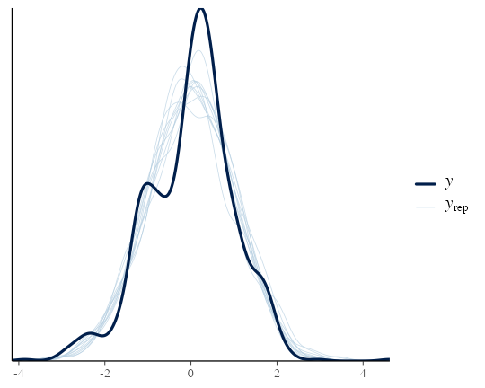

```r
pp_check(fit1, resp = "tarsus")
```

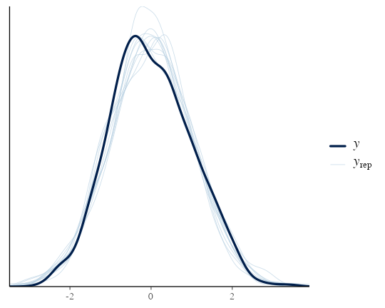

```r
pp_check(fit1, resp = "back")
```

This looks pretty solid, but we notice a slight unmodeled left skewness in the distribution of `tarsus`. We will come back to this later on. Next, we want to investigate how much variation in the response variables can be explained by our model and we use a Bayesian generalization of the $R^2$ coefficient.

```r
bayes_R2(fit1)
```

```
          Estimate  Est.Error      Q2.5     Q97.5
R2tarsus 0.4339423 0.02259243 0.3892020 0.4738335
R2back   0.1988869 0.02761764 0.1457193 0.2539534
```

Clearly, there is much variation in both animal characteristics that we can not explain, but apparently we can explain more of the variation in tarsus length than in back color.

## More Complex Multivariate Models

Now, suppose we only want to control for `sex` in `tarsus` but not in `back` and vice versa for `hatchdate`. Not that this is particular reasonable for the present example, but it allows us to illustrate how to specify different formulas for different response variables. We can no longer use `mvbind` syntax and so we have to use a more verbose approach:

```r
bf_tarsus <- bf(tarsus ~ sex + (1|p|fosternest) + (1|q|dam))
bf_back <- bf(back ~ hatchdate + (1|p|fosternest) + (1|q|dam))
fit2 <- brm(bf_tarsus + bf_back + set_rescor(TRUE),
            data = BTdata, chains = 2, cores = 2)
```

Note that we have literally *added* the two model parts via the `+` operator, which is in this case equivalent to writing `mvbf(bf_tarsus, bf_back)`. See `help("brmsformula")` and `help("mvbrmsformula")` for more details about this syntax. Again, we summarize the model first.

```r
fit2 <- add_criterion(fit2, "loo")
summary(fit2)
```

```
 Family: MV(gaussian, gaussian)
  Links: mu = identity
         mu = identity
Formula: tarsus ~ sex + (1 | p | fosternest) + (1 | q | dam)
         back ~ hatchdate + (1 | p | fosternest) + (1 | q | dam)
   Data: BTdata (Number of observations: 828)
  Draws: 2 chains, each with iter = 2000; warmup = 1000; thin = 1;
         total post-warmup draws = 2000

Multilevel Hyperparameters:
~dam (Number of levels: 106)
                                     Estimate Est.Error l-95% CI u-95% CI Rhat Bulk_ESS
sd(tarsus_Intercept)                     0.48      0.05     0.39     0.58 1.00      878
sd(back_Intercept)                       0.24      0.08     0.08     0.38 1.00      290
cor(tarsus_Intercept,back_Intercept)    -0.50      0.22    -0.94    -0.07 1.00      518
                                     Tail_ESS
sd(tarsus_Intercept)                     1162
sd(back_Intercept)                        483
cor(tarsus_Intercept,back_Intercept)      623

~fosternest (Number of levels: 104)
                                     Estimate Est.Error l-95% CI u-95% CI Rhat Bulk_ESS
sd(tarsus_Intercept)                     0.26      0.05     0.16     0.38 1.00      759
sd(back_Intercept)                       0.35      0.06     0.24     0.47 1.00      521
cor(tarsus_Intercept,back_Intercept)     0.66      0.21     0.19     0.97 1.02      311
                                     Tail_ESS
sd(tarsus_Intercept)                     1098
sd(back_Intercept)                        903
cor(tarsus_Intercept,back_Intercept)      479

Regression Coefficients:
                 Estimate Est.Error l-95% CI u-95% CI Rhat Bulk_ESS Tail_ESS
tarsus_Intercept    -0.41      0.07    -0.54    -0.28 1.00     1578     1207
back_Intercept       0.00      0.05    -0.10     0.10 1.00     1995     1541
tarsus_sexMale       0.77      0.06     0.65     0.89 1.00     4384     1440
tarsus_sexUNK        0.22      0.13    -0.03     0.48 1.01     3221     1534
back_hatchdate      -0.09      0.05    -0.18     0.02 1.00     1787     1210

Further Distributional Parameters:
             Estimate Est.Error l-95% CI u-95% CI Rhat Bulk_ESS Tail_ESS
sigma_tarsus     0.76      0.02     0.72     0.80 1.00     2188     1082
sigma_back       0.90      0.02     0.85     0.95 1.00     2439     1558

Residual Correlations:
                    Estimate Est.Error l-95% CI u-95% CI Rhat Bulk_ESS Tail_ESS
rescor(tarsus,back)    -0.05      0.04    -0.12     0.02 1.00     2721     1528

Draws were sampled using sampling(NUTS). For each parameter, Bulk_ESS
and Tail_ESS are effective sample size measures, and Rhat is the potential
scale reduction factor on split chains (at convergence, Rhat = 1).
```

Let’s find out, how model fit changed due to excluding certain effects from the initial model:

```r
loo(fit1, fit2)
```

```
Output of model 'fit1':

Computed from 2000 by 828 log-likelihood matrix.

         Estimate   SE
elpd_loo  -2127.2 33.7
p_loo       176.6  7.5
looic      4254.3 67.4
------
MCSE of elpd_loo is NA.
MCSE and ESS estimates assume MCMC draws (r_eff in [0.5, 1.8]).

Pareto k diagnostic values:
                         Count Pct.    Min. ESS
(-Inf, 0.7]   (good)     826   99.8%   106
   (0.7, 1]   (bad)        2    0.2%   <NA>
   (1, Inf)   (very bad)   0    0.0%   <NA>
See help('pareto-k-diagnostic') for details.

Output of model 'fit2':

Computed from 2000 by 828 log-likelihood matrix.

         Estimate   SE
elpd_loo  -2124.5 33.6
p_loo       174.0  7.3
looic      4249.1 67.2
------
MCSE of elpd_loo is NA.
MCSE and ESS estimates assume MCMC draws (r_eff in [0.4, 1.7]).

Pareto k diagnostic values:
                         Count Pct.    Min. ESS
(-Inf, 0.7]   (good)     827   99.9%   142
   (0.7, 1]   (bad)        0    0.0%   <NA>
   (1, Inf)   (very bad)   1    0.1%   <NA>
See help('pareto-k-diagnostic') for details.

Model comparisons:
     elpd_diff se_diff
fit2  0.0       0.0
fit1 -2.6       1.4
```

Apparently, there is no noteworthy difference in the model fit. Accordingly, we do not really need to model `sex` and `hatchdate` for both response variables, but there is also no harm in including them (so I would probably just include them).

To give you a glimpse of the capabilities of **brms**’ multivariate syntax, we change our model in various directions at the same time. Remember the slight left skewness of `tarsus`, which we will now model by using the `skew_normal` family instead of the `gaussian` family. Since we do not have a multivariate normal (or student-t) model, anymore, estimating residual correlations is no longer possible. We make this explicit using the `set_rescor` function. Further, we investigate if the relationship of `back` and `hatchdate` is really linear as previously assumed by fitting a non-linear spline of `hatchdate`. On top of it, we model separate residual variances of `tarsus` for male and female chicks.

```r
bf_tarsus <- bf(tarsus ~ sex + (1|p|fosternest) + (1|q|dam)) +
  lf(sigma ~ 0 + sex) + skew_normal()
bf_back <- bf(back ~ s(hatchdate) + (1|p|fosternest) + (1|q|dam)) +
  gaussian()

fit3 <- brm(
  bf_tarsus + bf_back + set_rescor(FALSE),
  data = BTdata, chains = 2, cores = 2,
  control = list(adapt_delta = 0.95)
)
```

Again, we summarize the model and look at some posterior-predictive checks.

```r
fit3 <- add_criterion(fit3, "loo")
summary(fit3)
```

```
 Family: MV(skew_normal, gaussian)
  Links: mu = identity; sigma = log
         mu = identity
Formula: tarsus ~ sex + (1 | p | fosternest) + (1 | q | dam)
         sigma ~ 0 + sex
         back ~ s(hatchdate) + (1 | p | fosternest) + (1 | q | dam)
   Data: BTdata (Number of observations: 828)
  Draws: 2 chains, each with iter = 2000; warmup = 1000; thin = 1;
         total post-warmup draws = 2000

Smoothing Spline Hyperparameters:
                       Estimate Est.Error l-95% CI u-95% CI Rhat Bulk_ESS Tail_ESS
sds(back_shatchdate_1)     1.90      0.99     0.26     4.20 1.00      368      346

Multilevel Hyperparameters:
~dam (Number of levels: 106)
                                     Estimate Est.Error l-95% CI u-95% CI Rhat Bulk_ESS
sd(tarsus_Intercept)                     0.47      0.05     0.38     0.58 1.00      763
sd(back_Intercept)                       0.23      0.07     0.09     0.37 1.00      311
cor(tarsus_Intercept,back_Intercept)    -0.52      0.23    -0.93    -0.05 1.00      516
                                     Tail_ESS
sd(tarsus_Intercept)                      979
sd(back_Intercept)                        333
cor(tarsus_Intercept,back_Intercept)      664

~fosternest (Number of levels: 104)
                                     Estimate Est.Error l-95% CI u-95% CI Rhat Bulk_ESS
sd(tarsus_Intercept)                     0.26      0.06     0.14     0.37 1.02      421
sd(back_Intercept)                       0.31      0.06     0.20     0.42 1.01      555
cor(tarsus_Intercept,back_Intercept)     0.64      0.23     0.13     0.97 1.01      165
                                     Tail_ESS
sd(tarsus_Intercept)                      638
sd(back_Intercept)                        891
cor(tarsus_Intercept,back_Intercept)      612

Regression Coefficients:
                     Estimate Est.Error l-95% CI u-95% CI Rhat Bulk_ESS Tail_ESS
tarsus_Intercept        -0.41      0.07    -0.55    -0.28 1.00     1045     1482
back_Intercept          -0.00      0.05    -0.11     0.10 1.00     1608     1571
tarsus_sexMale           0.77      0.06     0.65     0.89 1.00     3781     1474
tarsus_sexUNK            0.21      0.12    -0.02     0.44 1.00     1994     1581
sigma_tarsus_sexFem     -0.30      0.04    -0.38    -0.22 1.00     2928     1645
sigma_tarsus_sexMale    -0.25      0.04    -0.32    -0.17 1.00     2784     1529
sigma_tarsus_sexUNK     -0.39      0.13    -0.64    -0.14 1.00     2247     1535
back_shatchdate_1       -0.40      2.99    -5.56     6.41 1.00     1007     1129

Further Distributional Parameters:
             Estimate Est.Error l-95% CI u-95% CI Rhat Bulk_ESS Tail_ESS
sigma_back       0.90      0.02     0.85     0.95 1.00     2093     1434
alpha_tarsus    -1.24      0.40    -1.89    -0.26 1.00     1693      739

Draws were sampled using sampling(NUTS). For each parameter, Bulk_ESS
and Tail_ESS are effective sample size measures, and Rhat is the potential
scale reduction factor on split chains (at convergence, Rhat = 1).
```

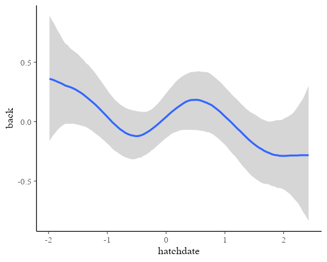

```r
conditional_effects(fit3, "hatchdate", resp = "back")
```

reveals a non-linear relationship of `hatchdate` on the `back` color, which seems to change in waves over the course of the hatch dates.

There are many more modeling options for multivariate models, which are not discussed in this vignette. Examples include autocorrelation structures, Gaussian processes, or explicit non-linear predictors (e.g., see `help("brmsformula")` or `vignette("brms_multilevel")`). In fact, nearly all the flexibility of univariate models is retained in multivariate models.

## References

Hadfield JD, Nutall A, Osorio D, Owens IPF (2007). Testing the phenotypic gambit: phenotypic, genetic and environmental correlations of colour. *Journal of Evolutionary Biology*, 20(2), 549-557.